# day1_compare_ORA_GSEA

The following code reads the expression matrix and the condition labels.

```r
library(CePa)
condition = read.cls("P53.cls", treatment = "MUT", control = "WT")$label
expr = read.gct("P53_collapsed_symbols.gct")
```

The analysis starts from here.

The following function converts gene IDs to EntreZ gene ID:

```r
convert_to_entrez_id = function(x, org_db = "org.Hs.eg.db") {
    if(is.matrix(x)) {
        map = cola:::guess_id_mapping(rownames(x), org_db = org_db)
        if(is.function(map)) {
            new_rn = map(rownames(x))
        } else {
            new_rn = map[rownames(x)]
        }
        l = is.na(new_rn)

        x = x[!l, , drop = FALSE]
        new_rn = new_rn[!l]

        x2 = do.call(rbind, tapply(1:nrow(x), new_rn, function(ind) {
            colMeans(x[ind, , drop = FALSE])
        }))
        return(x2)

    } else if(is.numeric(x)) {
        map = cola:::guess_id_mapping(names(x), org_db = org_db)
        x2 = x
        if(is.function(map)) {
            names(x2) = map(names(x))
        } else {
            names(x2) = map[names(x)]
        }
        x2 = x2[!is.na(names(x2))]
        x2 = tapply(x2, names(x2), mean)
        return(x2)
    } else {
        map = cola:::guess_id_mapping(x, org_db = org_db)
        if(is.function(map)) {
            x2 = map(x)
        } else {
            x2 = map[x]
        }
        x2 = x2[!is.na(x2)]
        x2 = unique(x2)
        return(x2)
    }
}
```

We convert gene IDs to Entrez IDs:

```r
expr = convert_to_entrez_id(expr)
```

```
## testing org.Hs.egENSEMBL...
```

```
## testing org.Hs.egREFSEQ...
```

```
## testing org.Hs.egSYMBOL...
##   gene id might be SYMBOL (p = 0.610)
```

We apply t-test to every gene.

```r
p = apply(expr, 1, function(x) {
    x1 = x[condition == "WT"]
    x2 = x[condition == "MUT"]

    t.test(x1, x2)$p.value
})
```

row* family functions

-rowMeans faster version of apply(mat, 1, mean) -rowSds apply(mat, 1, sd)

```r
library(genefilter)
tdf = rowttests(expr, factor(condition))  # the second must be a "factor"
tdf$fdr = p.adjust(tdf$p.value, "BH")
sum(tdf$fdr < 0.05)  # number of diff genes
```

```
## [1] 2
```

It seems there are not too many diff genes. We look at the distribution of the t-statistics:

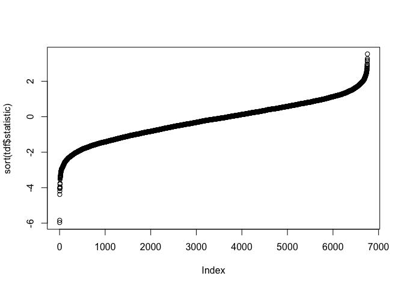

```r
plot(sort(tdf$statistic))
```

Instead of setting a cutoff for FDR, we set a cutoff for t-statistics, just to get enough number of diff genes.

```r
sum(abs(tdf$statistic) > 2)
```

```
## [1] 484
```

First we perform ORA, using GO BP gene sets:

```r
library(clusterProfiler)
library(org.Hs.eg.db)
l_sig = abs(tdf$statistic) > 2
tb_ora = enrichGO(gene  = rownames(expr)[l_sig],
                  OrgDb = org.Hs.eg.db,
                  ont   = "BP",
                  pAdjustMethod = "BH")
tb_ora = as.data.frame(tb_ora)
```

Then we perform GSEA, using t-statistics as gene scores. Note here the p-values are calculated by gene permutation.

```r
s = tdf$statistic
names(s) = rownames(tdf)   # s must have names (gene IDs)
s = sort(s, decreasing = TRUE)  # s must be pre-sorted
tb_gsea = gseGO(geneList = s,
                OrgDb = org.Hs.eg.db,
                ont   = "BP",
                pAdjustMethod = "BH")
tb_gsea = as.data.frame(tb_gsea)
```

We compare the two significant GO lists:

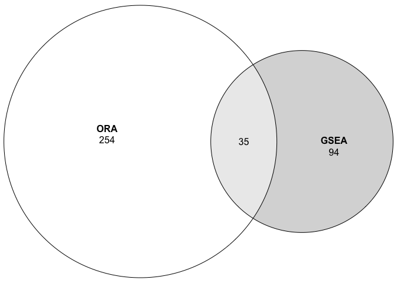

```r
library(eulerr)
plot(euler(list(ORA = tb_ora$ID, GSEA = tb_gsea$ID)), quantities = TRUE)
```

Recall ORA is sensitive to selection of background genes and cutoff of diff genes. Next we first set background for ORA, which is the total genes in the matrix:

```r
l_sig = abs(tdf$statistic) > 2
tb_ora_with_bg = enrichGO(gene = rownames(expr)[l_sig],
                  universe = rownames(expr),
                  OrgDb = org.Hs.eg.db,
                  ont   = "BP",
                  pAdjustMethod = "BH")
tb_ora_with_bg = as.data.frame(tb_ora_with_bg)
nrow(tb_ora_with_bg)
```

```
## [1] 0
```

OMG! If setting the background (6756 genes), there is no significant gene set anymore!

We also change the cutoff of gene-level t-statistics to 1.5, without background.

```r
l_sig = abs(tdf$statistic) > 1.5
tb_ora_1.5 = enrichGO(gene  = rownames(expr)[l_sig],
                  OrgDb = org.Hs.eg.db,
                  ont   = "BP",
                  pAdjustMethod = "BH")
tb_ora_1.5 = as.data.frame(tb_ora_1.5)
```

We compare the significant GO lists:

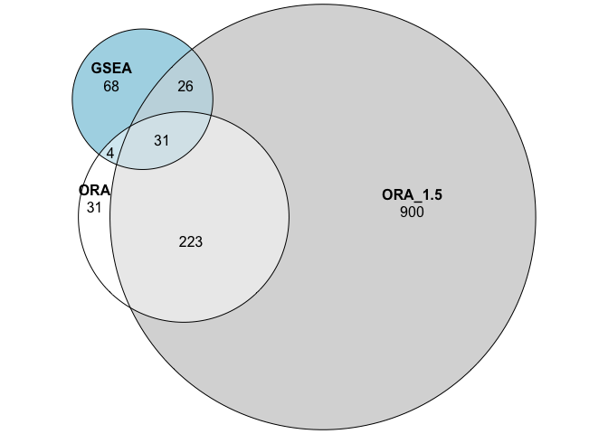

```r
plot(euler(list(ORA = tb_ora$ID,
                ORA_1.5 = tb_ora_1.5$ID,
                GSEA = tb_gsea$ID)),
    quantities = TRUE)
```